# Predicting Churn using Social Network Analysis with R

Lenox Low

September 28, 2018

This tutorial used the sample data to demonstrate the basic processes of performing social network analysis with R. The `igraph` library was used to do the social network analysis. You should install the latest version of `igraph` for R.

## (A) Import Libraries

```r
library("igraph")
library("data.table")
```

## (B) Import Data

```r
transaction <- read.csv("transaction_sample.csv", header=TRUE);
head(transaction)
```

```
##   PARTY_A PARTY_B CALL_DURATION CALL_COUNT
## 1   82457   91010           134          3
## 2   82457   48305            11          1
## 3   82457   19255            53          1
## 4   82457   35885            36          1
## 5   82457   61112            73          1
## 6   82457   88243           156          1
```

## (C) Data Preprocessing

Extract the unique MSISDN from the transaction data, then calculate the total incoming and outgoing call count and duration for each MSISDN. Two functions were created to extract the MSISDNs.

### (I) Extract unique MSISDN from the transaction data

```r
ExtractUniqueMSISDNList <- function(target.df) {
  temp1 <- unique(target.df$PARTY_A)
  temp2 <- unique(target.df$PARTY_B)
  temp <- c(temp1, temp2)

  m.list <- unique(temp)
  m.list <- data.frame(m.list)
  colnames(m.list)[1] <- "MSISDN"

  return(m.list)
}
subs <- ExtractUniqueMSISDNList(transaction)
```

### (II) Extract the transaction reecords of defined MSISDN.

```r
ExtractTransactionByMSISDN <- function(msisdn, target.df){
  sub.trans <- target.df[target.df$PARTY_A == msisdn | target.df$PARTY_B == msisdn, ]

  return(sub.trans)
}
```

Calculate the total call count and duration

```r
for(i in 1:nrow(subs)){
  subs$CALL_IN_DUR[i] <- sum(transaction$CALL_DURATION[transaction$PARTY_B == subs$MSISDN[i]])
  subs$CALL_OUT_DUR[i] <- sum(transaction$CALL_DURATION[transaction$PARTY_A == subs$MSISDN[i]])

  subs$CALL_IN_COUNT[i] <- sum(transaction$CALL_COUNT[transaction$PARTY_B == subs$MSISDN[i]])
  subs$CALL_OUT_COUNT[i] <- sum(transaction$CALL_COUNT[transaction$PARTY_A == subs$MSISDN[i]])

  subs$RELATION_COUNT[i] <- nrow(ExtractUniqueMSISDNList(ExtractTransactionByMSISDN(subs$MSISDN[i], transaction))) - 1
  subs$IN_RELATION[i] <- nrow(transaction[transaction$PARTY_B == subs$MSISDN[i], ])
  subs$OUT_RELATION[i] <- nrow(transaction[transaction$PARTY_A == subs$MSISDN[i], ])
}

subs$TOTAL_CALL_COUNT <- subs$CALL_IN_COUNT + subs$CALL_OUT_COUNT

head(subs)
```

```
##   MSISDN CALL_IN_DUR CALL_OUT_DUR CALL_IN_COUNT CALL_OUT_COUNT
## 1  82457       12741         8278           218            172
## 2  67686           0           68             0              2
## 3  40428           0           89             0              1
## 4  38865           0          121             0              3
## 5   3263           0           27             0              1
## 6  79679           0           28             0              1
##   RELATION_COUNT IN_RELATION OUT_RELATION TOTAL_CALL_COUNT
## 1             60          38           49              390
## 2              1           0            1                2
## 3              1           0            1                1
## 4              1           0            1                3
## 5              1           0            1                1
## 6              1           0            1                1
```

### (I) Data Cleansing

Set the boundary value for the cleansing criteria

```r
call.relation <- 30
call.count <- 30
call.mean <- mean(subs$TOTAL_CALL_COUNT)
call.duration <- 15
```

Label every MSIDSN based on the criteria stated below. CALL CENTER - Incoming call is greater than call count boundary No outgoing call Call relation count is greater than call relation count boundary TELESALES - Outgoing call is greater than call count boundary No incoming call Outgoing call divided by call relation count is less than the mean of the total call count NOISY - Incoming call count is 1 No outgoing call The call duration is less than the call duration boundary

```r
for(i in 1: nrow(subs)){
  if(subs$CALL_IN_COUNT[i] > call.count && subs$CALL_OUT_COUNT[i] == 0 && subs$RELATION_COUNT[i] > call.relation) {
    subs$TYPE[i] <- "CALL CENTER"
  } else if (subs$CALL_IN_COUNT[i] == 0 && subs$CALL_OUT_COUNT[i] > call.count && subs$CALL_OUT_COUNT[i] / subs$RELATION_COUNT[i] < call.mean) {
    subs$TYPE[i] <- "TELESALES"
  } else if (subs$CALL_IN_COUNT[i] == 1 && subs$CALL_OUT_COUNT[i] == 0 && subs$CALL_IN_DUR[i] < call.duration) {
    subs$TYPE[i] <- "NOISY"
  } else {
    subs$TYPE[i] <- "NORMAL"
  }
}

normal.msisdn <- subs[subs$TYPE == "NORMAL",]
```

Get the transaction records of normal MSISDN only and calculate average duration per call (Weight) betwen two MSISDNs.

```r
filtered.transaction <- transaction[transaction$PARTY_A %in% normal.msisdn$MSISDN & transaction$PARTY_B %in% normal.msisdn$MSISDN,]
filtered.transaction$Weight <- filtered.transaction$CALL_DURATION / filtered.transaction$CALL_COUNT
head(filtered.transaction)
```

```
##   PARTY_A PARTY_B CALL_DURATION CALL_COUNT    Weight
## 1   82457   91010           134          3  44.66667
## 3   82457   19255            53          1  53.00000
## 4   82457   35885            36          1  36.00000
## 5   82457   61112            73          1  73.00000
## 6   82457   88243           156          1 156.00000
## 7   82457   83190            26          1  26.00000
```

### (II) Transform Data Frame to Matrix

```r
msisdn.list <- ExtractUniqueMSISDNList(filtered.transaction)
ma <- matrix(0, ncol=nrow(msisdn.list), nrow=nrow(msisdn.list))
madf <- data.frame(ma)

colnames(madf) <- msisdn.list$MSISDN
row.names(madf) <- msisdn.list$MSISDN

filtered.transaction$PARTY_A <- as.character(filtered.transaction$PARTY_A)
filtered.transaction$PARTY_B <- as.character(filtered.transaction$PARTY_B)

for(i in 1:nrow(filtered.transaction)) {
  madf[filtered.transaction[i,"PARTY_A"], filtered.transaction[i,"PARTY_B"]] <- filtered.transaction[i, "Weight"]
}
ma <- as.matrix(madf)
ma[1:6, 1:6]
```

```
##          82457 67686 40428 38865 3263 79679
## 82457 55.69231     0     0     0    0     0
## 67686 34.00000     0     0     0    0     0
## 40428 89.00000     0     0     0    0     0
## 38865 40.33333     0     0     0    0     0
## 3263  27.00000     0     0     0    0     0
## 79679 28.00000     0     0     0    0     0
```

## (D) Social Network Analysis (SNA)

### (I) Build the network

```r
net <- graph.adjacency(ma, mode="directed", weighted=TRUE, diag=FALSE)
```

### (II) Generate Result

#### (1) Closeness Centrality - how fast can a node reach everyone in the network.

```r
res.closeness <- closeness(net)
res <- setDT(data.frame(res.closeness), keep.rownames = TRUE)[]
colnames(res)[1] <- "MSISDN"
colnames(res)[2] <- "Closeness"
res$MSISDN <- as.numeric(res$MSISDN)

res.closeness[1:5]
```

```
##        82457        67686        40428        38865         3263
## 0.0003509461 0.0002314579 0.0001471575 0.0002171345 0.0002496605
```

#### (2) Degree Centrality - the number of links connected to a node.

```r
res <- cbind(res, degree(net))
colnames(res)[ncol(res)] <- "Degree"

degree(net)[1:5]
```

```
## 82457 67686 40428 38865  3263
##    79     1     1     1     1
```

#### (3) Betweenness Centrality - the extent to which a node lies on shortest paths between other nodes.

```r
res <- cbind(res, betweenness(net))
colnames(res)[ncol(res)] <- "Betweenness"

betweenness(net)[1:5]
```

```
## 82457 67686 40428 38865  3263
##  1519     0     0     0     0
```

#### (4) Eigenvector Centrality - influence of a node in a network.

```r
res <- cbind(res, eigen_centrality(net)$vector)
colnames(res)[ncol(res)] <- "Eigenvector"

eigen_centrality(net)$vector[1:5]
```

```
##      82457      67686      40428      38865       3263
## 1.00000000 0.05264161 0.13779715 0.06244740 0.04180363
```

Result overview

```r
head(res)
```

```
##    MSISDN    Closeness Degree Betweenness Eigenvector
## 1:  82457 0.0003509461     79        1519  1.00000000
## 2:  67686 0.0002314579      1           0  0.05264161
## 3:  40428 0.0001471575      1           0  0.13779715
## 4:  38865 0.0002171345      1           0  0.06244740
## 5:   3263 0.0002496605      1           0  0.04180363
## 6:  79679 0.0002468868      1           0  0.04335191
```

#### (5) Density - total number of edges over total edges

```r
density <- edge_density(net, loops=FALSE)
density
```

```
## [1] 0.02367037
```

#### (6) Reciprocity - the ratio of edges which are dual-directed over total edges

```r
reciprocity <- reciprocity(net)
reciprocity
```

```
## [1] 0.5185185
```

## Plots the network

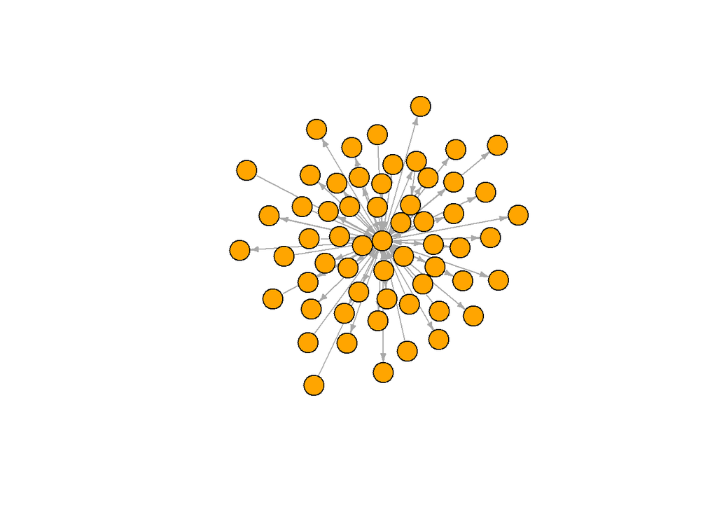

```r
V(net)$color=V(net)$name
V(net)$color=gsub("82457","red","orange")
plot(net, edge.arrow.size=.4,vertex.label=NA)
```